## Climate Impacts on Agricultural Productivity in the Fruitful Rim

##### 9th Annual Northwest Climate Conference - Boise, ID

##### [#NWCC2018](https://twitter.com/search?q=%23NWCC2018)

Nicholas Potter, Michael Brady, Kirti Rajagopalan

Washington State University

October 10, 2018

[figure not shown]

## Temperature and irrigated land rents

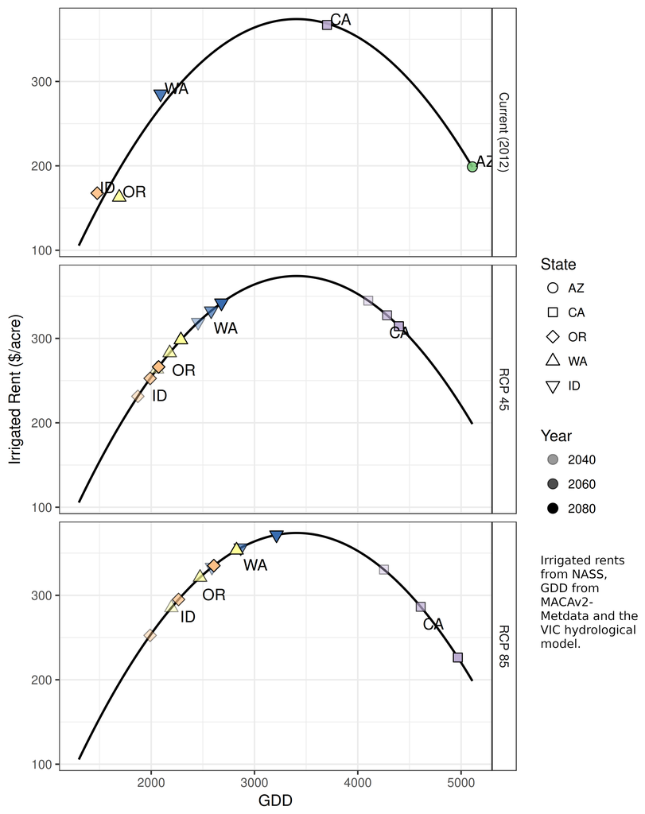

## Are outcomes enough?

We seek a

“credible description of adaptation behaviors under uncertainty.” – Hallegatte, Hourcade, and Ambrosi (2007)

## Two Approaches: Framing the Debate

How do we capture the impacts of climate when both crops and people can adapt to changing conditions?

- Producers adapt via crop-switching or other methods (Mendelsohn, Nordhaus, and Shaw 1994) (MNS)
- Yield response is non-linear (Schlenker and Roberts 2009; Schlenker, Hanemann, and Fisher 2005) (SR)

*A review of the literature in Blanc and Reilly (2017).*

## Estimating effects on income using a cross-sectional approach

- Ricardian assumption (markets clear) that income and land values reflect efficient production and perfect adaptation to climate (but how?)
- Omitted variable bias (an important variable that determines land values isn’t included).

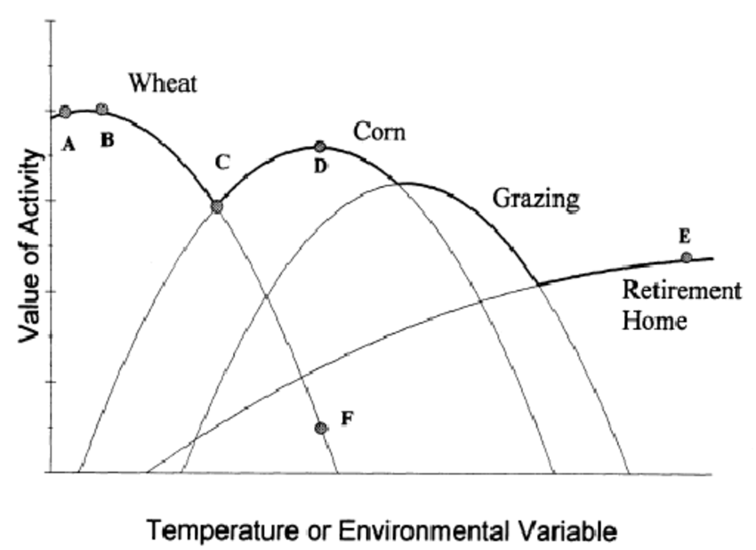

(Figure from MNS 1994.)

## Estimating effects on yields using panel data

- Isolate non-linear yield-temperature relationship.
- Clear identification via fixed effects (i.e. county-level time-invariant effects are nullified).
- Assumes producers make short run adaptations in the same way they would adapt long-term.
- Doesn’t allow for producer adaptation.

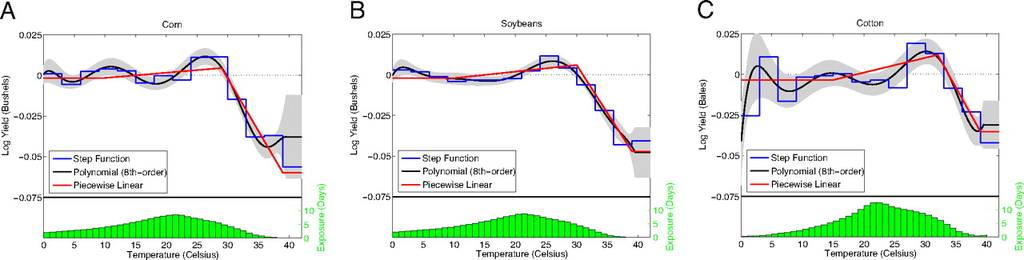

(Figure from SR 2009.)

## How can producers adapt?

- Switch to different crops that do better in new climate.
- Develop hardier varieties.
- Capital investments to manage temperature.
- Adjust crop intensity (multiple harvests).

## Research personal ad

> “Seeking climate effect estimation method that allows for imperfect farmer adaptation and examination of relative uptake of different adaptation strategies. Must minimize omitted variable bias. No OLS.”

## One approach - “long differences”

Long differences suggests that little of the short term fluctuation in weather is attenuated by adaptation to long run climate (Burke and Emerick 2016):

$$\Delta \bar{y}_{i} = \beta_1 \Delta \bar{z}_{i} + \beta_2 \bar{z}^2_{i} + \Delta \varepsilon_{i}.$$

where $\bar{z}$ is a vector of averaged climate variables and $\bar{y}$ is the averaged outcome, with the difference taken between averages over a “long” period.

- *but analysis is in the south, where primary crops are corn, soy, and cotton. These crops allow for relatively little adaptation by crop switching or crop-intensity adjustment.*

## Our approach

Outcome of interest is **irrigated rent**:

- Rents reflect expectations about land productivity over the period of the lease.
- Expectations about land productivity reflect expectations about climate and ability to adapt in the short run.

Region of interest is the **western fruitful rim**:

- Diverse high-value crop production (e.g. apples, grapes, potatoes, etc…) suggests multiple adaptation strategies.
- Irrigation fed by snowpack melt unlike eastern U.S. and dryland farming regions.

## Our approach

1. Use matching to find the historical climate analogue for 30-year average of projected climate in each county.
2. Difference between rental value of agricultural land in matched counties is estimate of the effect of climate on agricultural productivity.
3. Difference in crop mix, crop intensity suggest adaptation strategies.

## Benefits of matching

- Consistent approach to estimating both outcome and adaptations related to that outcome.
- Can examine specific matches for validity.
- Reduces bias due to omitted variables through improved covariate balance.

## Data process

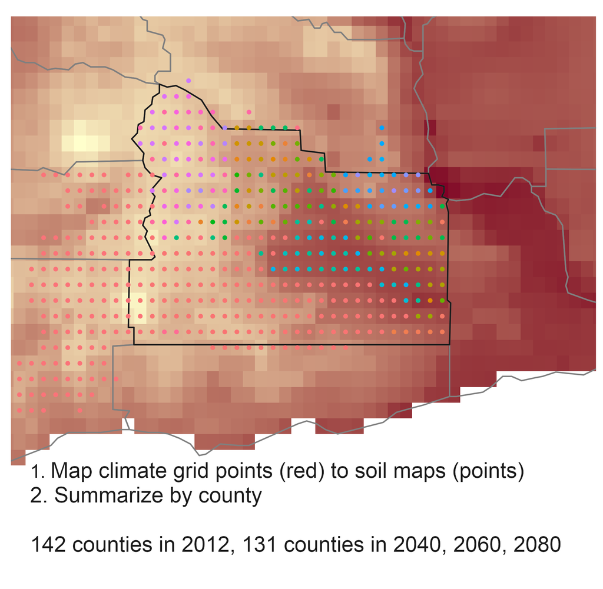

## Matching model

Our case is unusual in that $Y_i(0) \;$ is known and $Y_i(1) \;$ is unknown for all $i$.

$$\hat{Y}_i(1) = Y_m(0), \; m = \arg \min \limits_j \; GMD(Z_i, Z_j, k).$$

where $Z_i = \{\pi(X_i), X_i\}$ and $X_i$ consists of:

- distribution of hours in 3-degree temperature bins$^*$ ((<0], (0-3], (3-6], …, (36-39], (39+)),
- accumulated rain and growing season length,
- proportion of silt, sand, and clay.

## Before matching

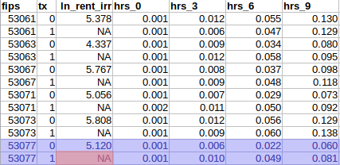

## Results: Western fruitful rim

[output not shown]

## Results: Western fruitful rim

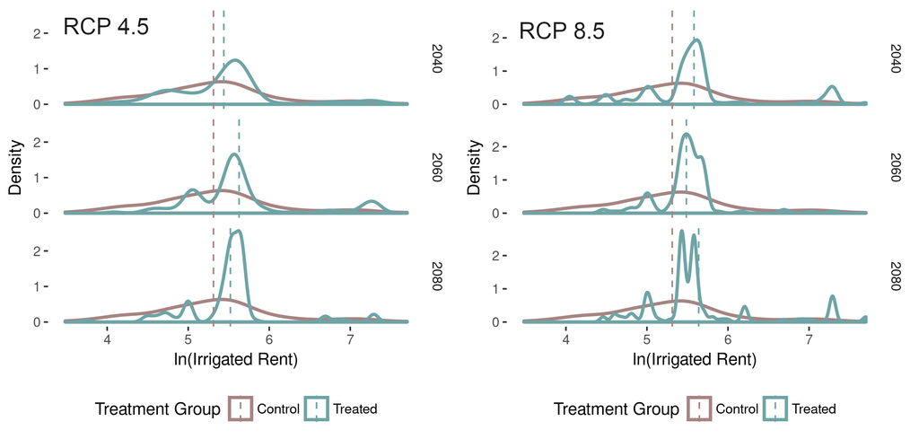

## Going forward

- Account for the effect of snowpack changes on water available for irrigation
- Downstream transportation and processing infrastructure frictions
- General equilibrium effects
- Empirical measure of crop mix difference between matches

## Evaluating covariate balance: better balance

Hours 33-36

|  | Before | After |
| --- | --- | --- |
| **Co mean** | 0.02242 | 0.0264 |
| **Tr mean** | 0.02735 | 0.02735 |
| **Std diff** | 26 | 5.022 |
| **Co var** | 0.00049 | 0.00036 |
| **Tr var** | 0.00036 | 0.00036 |
| **Var ratio** | 0.7386 | 0.9827 |
| **KS stat** | 0.2592 | 0.1069 |
| **KS boot p** | 0 | 0.414 |

## Evaluating covariate balance: worse balance

Avg max temp

|  | Before | After |
| --- | --- | --- |
| **Co mean** | 0.2625 | 0.2606 |
| **Tr mean** | 0.261 | 0.261 |
| **Std diff** | -4.854 | 1.158 |
| **Co var** | 0.00095 | 8e-04 |
| **Tr var** | 0.00092 | 0.00092 |
| **Var ratio** | 0.9749 | 1.147 |
| **KS stat** | 0.0915 | 0.1298 |
| **KS boot p** | 0.558 | 0.234 |

## Kolmogorov-Smirnov tests

|  | Before | After |
| --- | --- | --- |
| **Hours <0** | 0.022 | 0.004 |
| **Hours 6-9** | 0.03 | 0.072 |
| **Hours 9-12** | 0.228 | 0.004 |
| **Hours 27-30** | 0.33 | 0.01 |
| **Hours 30-33** | 0 | 0.098 |
| **Hours 33-36** | 0 | 0.414 |
| **Hours 36-39** | 0 | 0.114 |
| **Avg max temp** | 0.558 | 0.234 |
| **Avg min temp** | 0.026 | 0.004 |
| **Heat days** | 0 | 0.026 |
| **Silt** | 0.956 | 0.012 |
| **Clay** | 0.734 | 0.01 |
| **Sand** | 0.938 | 0.104 |
| **Latitude** | 0.81 | 0 |

*Note:* Values are bootstrapped p-values from a univariate Kolmogorov-Smirnov test of equal balance in estimated probabilities between treated and control groups.

## Contact

Nicholas A Potter

Washington State University

nicholas.a.potter@wsu.edu

twitter: potterzot

github: potterzot

## Selected References

Blanc, Elodie, and John Reilly. 2017. “Approaches to Assessing Climate Change Impacts on Agriculture: An Overview of the Debate.” *Review of Environmental Economics and Policy* 11 (2). Oxford University Press (OUP):247–57. https://doi.org/10.1093/reep/rex011.

Burke, Marshall, and Kyle Emerick. 2016. “Adaptation to Climate Change: Evidence from Us Agriculture.” *American Economic Journal: Economic Policy* 8 (3). American Economic Association:106–40. https://doi.org/10.1257/pol.20130025.

Hallegatte, Stéphane, Jean-Charles Hourcade, and Philippe Ambrosi. 2007. “Using Climate Analogues for Assessing Climate Change Economic Impacts in Urban Areas.” *Climatic Change* 82 (1-2). Springer Nature:47–60. https://doi.org/10.1007/s10584-006-9161-z.

Mendelsohn, Robert, William Nordhaus, and Daigee Shaw. 1994. “The Impact of Global Warming on Agriculture: A Ricardian Analysis.” *The American Economic Review*. JSTOR, 753–71.

Schlenker, Wolfram, and M. J. Roberts. 2009. “Nonlinear Temperature Effects Indicate Severe Damages to U.S. Crop Yields Under Climate Change.” *Proceedings of the National Academy of Sciences* 106 (37):15594–8. https://doi.org/10.1073/pnas.0906865106.

Schlenker, Wolfram, Michael W Hanemann, and Anthony C Fisher. 2005. “Will U.s. Agriculture Really Benefit from Global Warming? Accounting for Irrigation in the Hedonic Approach.” *American Economic Review* 95 (1). American Economic Association:395–406. https://doi.org/10.1257/0002828053828455.